# Vizualization

## Modules

- Matplotlib
- Seaborn: targets statistical data visualization
- Seaborn is complimentary to Matplotlib
- Seaborn:
  - creates aesthetically pleasing plots by default
  - creates statistically meaningful plots
  - understands the pandas DataFrame
  - is not directly included in Anaconda’s release

## Seaborn plots

- broadly divided into two classes:
  - “Axes-level” functions: regplot, boxplot, kdeplot
  - “Figure-level” functions: lmplot, factorplot, jointplot
- axes-level functions will only draw onto an axes and won’t otherwise mess with the figure
- figure level: the functions need to have total control over the figure
- figure level: fig and axes arguments, customization has to come after you’ve called the function

## Statistically meaningful plots

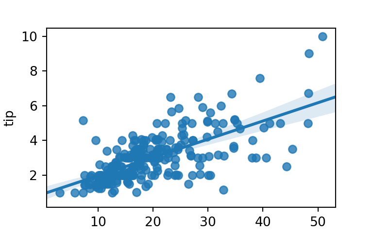

```python
import seaborn as sns
import matplotlib.pyplot as plt

# Load one of the data sets that come with seaborn
tips = sns.load_dataset("tips")

sns.regplot(x="total_bill", y="tip", data=tips)
```

## Linear regression

- lmplot
- regplot
- parameters:
  - hue: color by categories
  - col/row: facets
  - fit_reg: regression line
  - ci: confidential intervals
  - order: polyinominal fitting curve

## Tips dataset

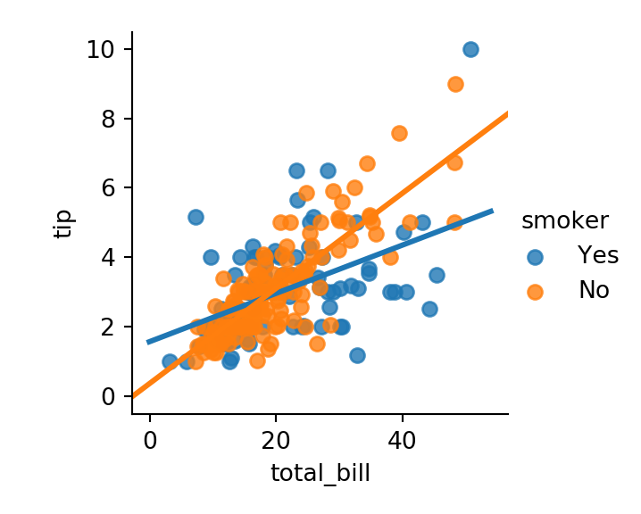

```python
tips = sns.load_dataset("tips")
lm=sns.lmplot(x="total_bill", y="tip", hue="smoker", data=tips, ci=None, size=3)
```

## Additional meta data through matplotlib

[figure not shown]

```python
plt.title('Total bill vs. tip')
# Set x-axis label
plt.xlabel('Total bill')
plt.ylabel('Tip ($)')
```

## Facet

- col or row

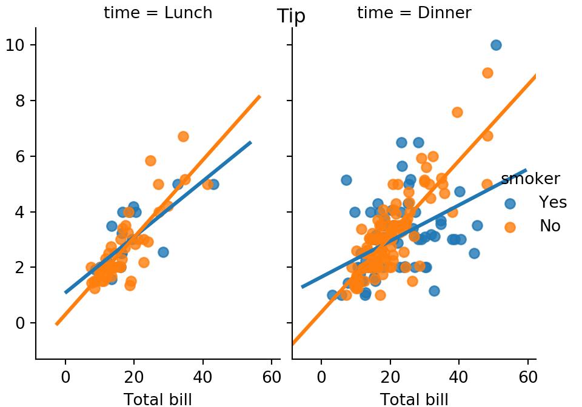

```python
lm=sns.lmplot(x="total_bill", y="tip", hue="smoker",
data=tips, col="time", ci=None)
lm.fig.suptitle("Tip")
lm.set_axis_labels("Total bill")
```

## Barchart (1)

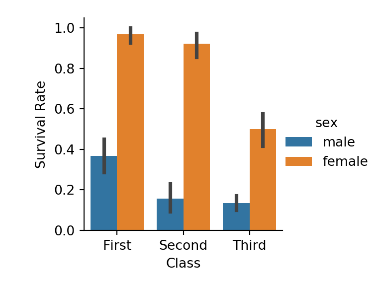

```python
titanic = sns.load_dataset("titanic")
g = sns.catplot(x="class", y="survived", hue="sex", data=titanic,
                height=3, kind="bar")
g.set_axis_labels("Class", "Survival Rate")
```

## Barchart (2)

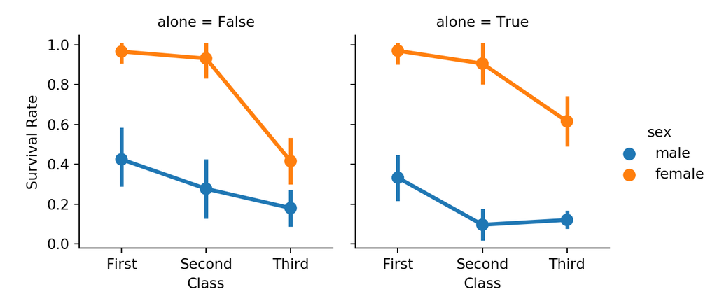

```python
titanic = sns.load_dataset("titanic")
g = sns.catplot(x="class", y="survived", hue="sex", data=titanic,
                height=3, kind="point", col="alone")
g.set_axis_labels("Class", "Survival Rate")
```

## Lab

Import CarsCSV.csv and show Quantity by Manufacturer and Year (facet). Show only data for Volkswagen, Toyota and Skoda for year 2007 and 2008. Mind the whitespace after the value in columns. Use str.strip() to trim.

## Solution

```python
import seaborn as sns
import matplotlib.pyplot as plt
import pandas as pd

df=pd.read_csv("./Lab/Datasets/CarsCSV.csv")

df=df[["Year","Manufacturer","Quantity"]]

df=df[(df["Manufacturer"].str.strip()=="Toyota") |
(df["Manufacturer"].str.strip()=="Volkswagen") |
(df["Manufacturer"].str.strip()=="Skoda")]

df=df[(df["Year"]==2007) | (df["Year"]==2008)]

df=df.groupby(["Manufacturer","Year"], as_index=False).sum()

sns.catplot(x="Manufacturer", y="Quantity",  kind="bar", col="Year", data=df, height=3)
```

## Lab

Take Titanic dataset and show survival rate according to alone variable. What is the average survival rate by alone? *Is there a statistical significant difference in survival rate?*

## Solution (1)

```python
import seaborn as sns
import matplotlib.pyplot as plt
import pandas as pd
from scipy import stats

titanic = sns.load_dataset("titanic")
df=titanic[["survived","alone"]]


dfa=df["survived"][df["alone"]==True]
dfna=df["survived"][df["alone"]==False]

print("Alone:",dfa.mean())
```

```
## Alone: 0.30353817504655495
```

```python
print("Not alone:",dfna.mean())
```

```
## Not alone: 0.5056497175141242
```

## Solution (2)

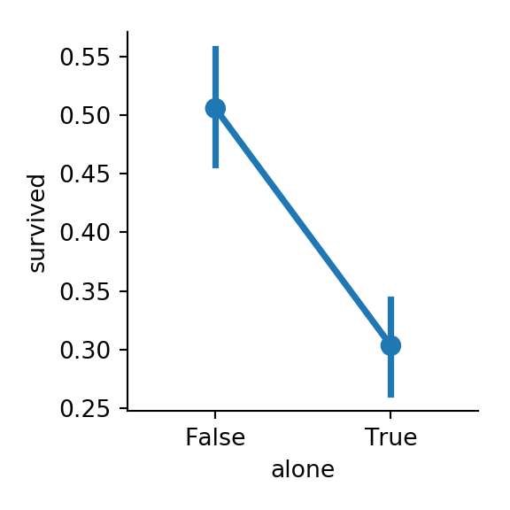

```python
g = sns.catplot(x="alone", y="survived", data=df,
                height=3, kind="point")
```

```python
print("T-test:",stats.ttest_ind(dfa, dfna))
```

```
## T-test: Ttest_indResult(statistic=-6.193032488079412, pvalue=9.009490179329723e-10)
```

## Combining plots

- stripplot
- boxplot

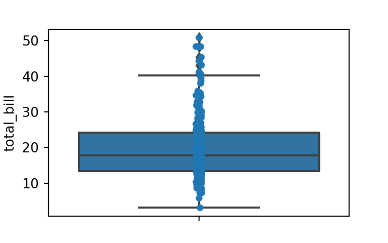

```python
import seaborn as sns
import matplotlib.pyplot as plt

tips = sns.load_dataset("tips")
sns.stripplot(y="total_bill", data=tips, jitter=0.01)
sns.boxplot(y="total_bill", data=tips)
```